# IODS course project

## Linear discriminant analysis

After some pretreatment with the data I provided linear discriminant analysis. I used as a target variable *crim_scaled*. I used all other variables as predictors.

```r
lda.fit <- lda(crime ~ ., data = train)

lda.fit
```

```
## Call:
## lda(crime ~ ., data = train)
##
## Prior probabilities of groups:
##       low   med_low  med_high      high
## 0.2698020 0.2376238 0.2450495 0.2475248
##
## Group means:
##                  zn      indus        chas        nox         rm
## low       0.9741228 -0.9208461 -0.09172814 -0.8764907  0.5115194
## med_low  -0.1254643 -0.3162355 -0.02626030 -0.5691819 -0.1239251
## med_high -0.3815632  0.1944991  0.24466389  0.3394549  0.1577679
## high     -0.4872402  1.0171519 -0.03610305  1.0834265 -0.4874979
##                 age        dis        rad        tax    ptratio
## low      -0.8950007  0.8557916 -0.6773694 -0.7582709 -0.4227204
## med_low  -0.3247950  0.3722769 -0.5535887 -0.4818898 -0.0352743
## med_high  0.4002476 -0.3549805 -0.3728357 -0.2874095 -0.3116594
## high      0.8158802 -0.8498837  1.6377820  1.5138081  0.7803736
##                black       lstat         medv
## low       0.37764824 -0.80182859  0.598537138
## med_low   0.30717465 -0.15696206 -0.002887466
## med_high  0.08352676 -0.04440567  0.236407500
## high     -0.78012857  0.87752175 -0.656163752
##
## Coefficients of linear discriminants:
##                  LD1          LD2         LD3
## zn       0.062712432  0.791091104 -0.82916408
## indus    0.038705620 -0.414958545  0.08338835
## chas    -0.063177849 -0.088479958  0.07256780
## nox      0.470113207 -0.484617631 -1.37163989
## rm      -0.095318489 -0.080398321 -0.19567276
## age      0.283619425 -0.377893095 -0.03079698
## dis      0.009914021 -0.367612238  0.22959107
## rad      2.922346316  0.910590848 -0.08221579
## tax      0.017042944 -0.023970759  0.67917329
## ptratio  0.126940347  0.123867855 -0.16998391
## black   -0.149162149  0.001918748  0.11461778
## lstat    0.233216794 -0.205274201  0.33885450
## medv     0.233812792 -0.285679168 -0.23926232
##
## Proportion of trace:
##    LD1    LD2    LD3
## 0.9452 0.0404 0.0143
```

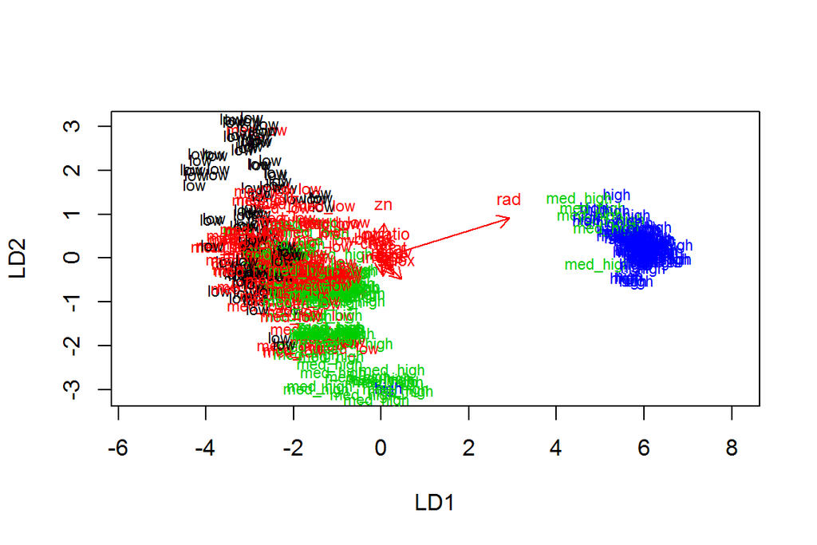

```r
lda.arrows <- function(x, myscale = 1, arrow_heads = 0.1, color = "red", tex = 0.75, choices = c(1,2)){
  heads <- coef(x)
  arrows(x0 = 0, y0 = 0,
         x1 = myscale * heads[,choices[1]],
         y1 = myscale * heads[,choices[2]], col=color, length = arrow_heads)
  text(myscale * heads[,choices], labels = row.names(heads),
       cex = tex, col=color, pos=3)
}

classes <- as.numeric(train$crime)

plot(lda.fit, dimen = 2, col = classes, pch = classes)
lda.arrows(lda.fit, myscale = 1)
```

After that I try to predict results with my test data. I remove variable *crime* from the data and calculate them again with my model

```r
correct_classes <- test$crime
test <- dplyr::select(test, -crime)

lda.pred <- predict(lda.fit, newdata = test)
table(correct = correct_classes, predicted = lda.pred$class)
```

```
##           predicted
## correct    low med_low med_high high
##   low       10       7        1    0
##   med_low    9      16        5    0
##   med_high   0      13       14    0
##   high       0       0        0   27
```

## K-means

```r
dist_eu <- dist(Boston)
summary(dist_eu)
```

```
##    Min. 1st Qu.  Median    Mean 3rd Qu.    Max.
##   1.119  85.620 170.500 226.300 371.900 626.000
```

Distances have mean 226. The lowest value is little over 1 and the highest value is 626.

Next step is to do some k-means clustering. But before that I tried to find optimal value for the number of clusters.

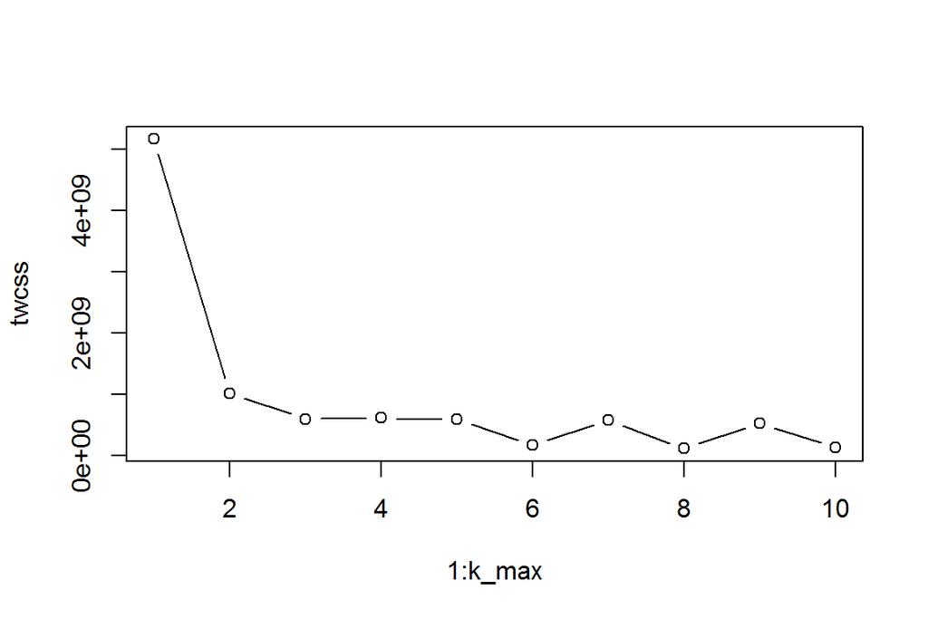

```r
set.seed(123)

k_max <- 10
twcss <- sapply(1:k_max, function(k){kmeans(dist_eu, k)$tot.withinss})

plot(1:k_max, twcss, type='b')
```

Optimal value seems to be 2.

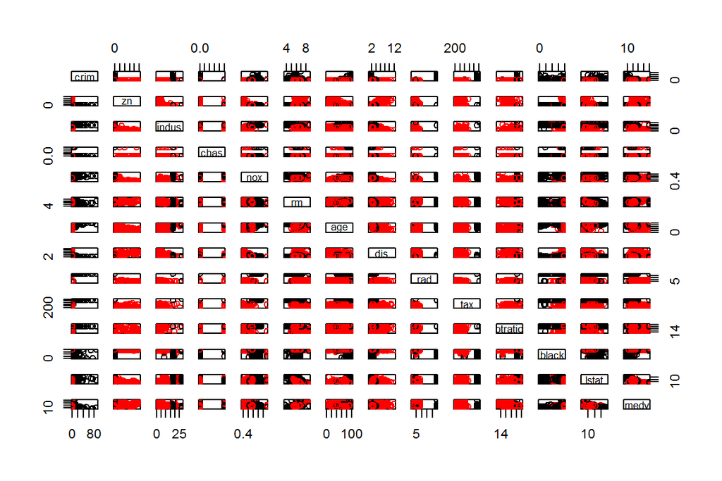

```r
km <-kmeans(dist_eu, centers = 2)

pairs(Boston, col = km$cluster)
```

# Dimensionality reduction techniques

The theme of the fifth week was dimensionality reduction techniques.

## Data

Some wrangling was done last week so I continued that one in separate file.

```r
summary(human_data)
```

```
##  gender_edu_ratio gender_lab_ratio    life_exp      exp_edu_year
##  Min.   :0.1717   Min.   :0.1857   Min.   :49.00   Min.   : 5.40
##  1st Qu.:0.7264   1st Qu.:0.5984   1st Qu.:66.30   1st Qu.:11.25
##  Median :0.9375   Median :0.7535   Median :74.20   Median :13.50
##  Mean   :0.8529   Mean   :0.7074   Mean   :71.65   Mean   :13.18
##  3rd Qu.:0.9968   3rd Qu.:0.8535   3rd Qu.:77.25   3rd Qu.:15.20
##  Max.   :1.4967   Max.   :1.0380   Max.   :83.50   Max.   :20.20
##      gni_pc       mat_mor_ratio     adol_birrate      repr_parl
##  Min.   :   581   Min.   :   1.0   Min.   :  0.60   Min.   : 0.00
##  1st Qu.:  4198   1st Qu.:  11.5   1st Qu.: 12.65   1st Qu.:12.40
##  Median : 12040   Median :  49.0   Median : 33.60   Median :19.30
##  Mean   : 17628   Mean   : 149.1   Mean   : 47.16   Mean   :20.91
##  3rd Qu.: 24512   3rd Qu.: 190.0   3rd Qu.: 71.95   3rd Qu.:27.95
##  Max.   :123124   Max.   :1100.0   Max.   :204.80   Max.   :57.50
```

```r
str(human_data)
```

```
## 'data.frame':    155 obs. of  8 variables:
##  $ gender_edu_ratio: num  0.198 0.931 0.861 0.977 0.989 ...
##  $ gender_lab_ratio: num  0.199 0.685 0.211 0.633 0.747 ...
##  $ life_exp        : num  60.4 77.8 74.8 76.3 74.7 82.4 81.4 70.8 75.4 76.6 ...
##  $ exp_edu_year    : num  9.3 11.8 14 17.9 12.3 20.2 15.7 11.9 12.6 14.4 ...
##  $ gni_pc          : int  1885 9943 13054 22050 8124 42261 43869 16428 21336 38599 ...
##  $ mat_mor_ratio   : int  400 21 89 69 29 6 4 26 37 22 ...
##  $ adol_birrate    : num  86.8 15.3 10 54.4 27.1 12.1 4.1 40 28.5 13.8 ...
##  $ repr_parl       : num  27.6 20.7 25.7 36.8 10.7 30.5 30.3 15.6 16.7 15 ...
```

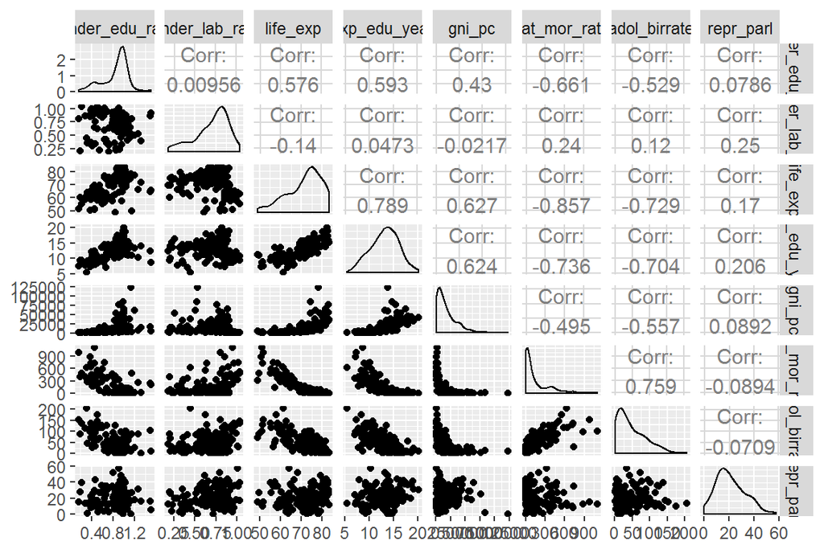

```r
ggpairs(human_data)
```

Ratios with edu and lab are numerical and their means are less than 1, but there is countries where ratios are more than 1 (portition of females are larger). GNIs are very different, but that is expected. Also maternal mortality ratios are very different between different countries.

There is also some correlations. There are high correlations between for example maternal mortality ratio and life expectancy; life expectancy and expected years of education; adolescent birth rate and maternal mortality ratio.

It seems that most of countries are poor one (or there is a few very rich country). Values are distributed very differently between different variables.

## Principal component analysis

```r
pca_human_nonSTD <- prcomp(human_data)
summary_pca_nonSTD <- summary(pca_human_nonSTD)
pca_pr_nonSTD <- round(1*summary_pca_nonSTD$importance[2, ], digits = 3) * 100
print(pca_pr_nonSTD)
```

```
## PC1 PC2 PC3 PC4 PC5 PC6 PC7 PC8
## 100   0   0   0   0   0   0   0
```

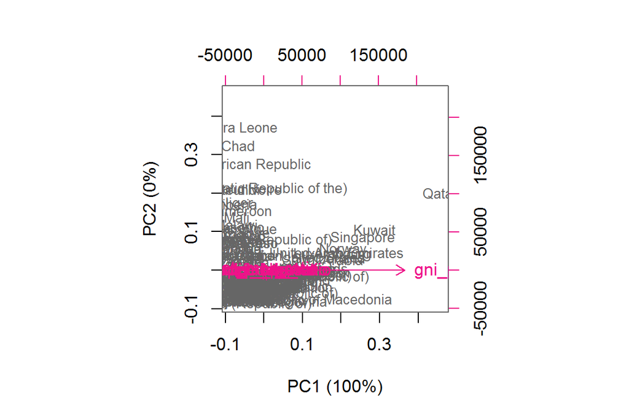

```r
pc_lab_nonSTD <- paste0(names(pca_pr_nonSTD), " (", pca_pr_nonSTD, "%)")
biplot(pca_human_nonSTD, cex = c(0.8, 1), col = c("grey40", "deeppink2"), xlab = pc_lab_nonSTD[1], ylab = pc_lab_nonSTD[2])
```

```r
human_data_STD <- scale(human_data)
pca_human_STD <- prcomp(human_data_STD)
summary_pca_STD <- summary(pca_human_STD)
pca_pr_STD <- round(1*summary_pca_STD$importance[2, ], digits = 3) * 100
print(pca_pr_STD)
```

```
##  PC1  PC2  PC3  PC4  PC5  PC6  PC7  PC8
## 53.6 16.2  9.6  7.6  5.5  3.6  2.6  1.3
```

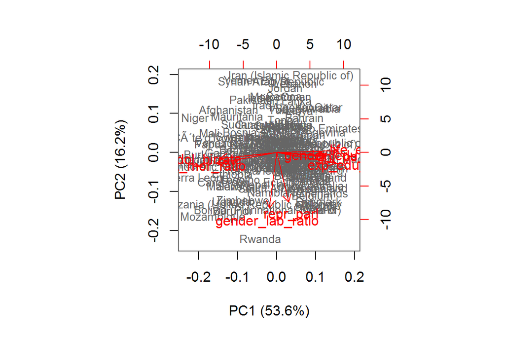

```r
pc_lab_STD <- paste0(names(pca_pr_STD), " (", pca_pr_STD, "%)")
biplot(pca_human_STD, cex = c(0.8, 1), col = c("grey40", "red"), xlab = pc_lab_STD[1], ylab = pc_lab_STD[2])
```

Before standardization biplot is quite different than after standardization. It seems that GNI affects more than other variables so rich countries are on the right-hand side. Without standardization the first component explains 100 % of variance. After scailing the first component captures 54 % and the second one 16 % of the variace. The reason for the difference is that the PCA keeps all variables equal. That means that if value (mean) is larger than others, that variable affects more to the PCA.

Bacause adding captions to the messy plot would make it even more messier, I will add some notations in the text. There is pointing two dimensions downwards. Those represent share of women in the economy and in the parliament. Bigger shares will affect to the PCA2 so that they make its value lower. To the right (higher values in PC1) is about education and life expectancy so more about the standards of living. Lower values in PC1 corresponds to mortality rate and birthrate.

## Multiple Correspondence Analysis

For the multiple correspondence analysis is needed a new dataset. I choose only some columns. The used dataset is a survey about tea. It has 300 observations in 36 variables.

```r
mca_tea <- MCA(tea_data, ncp = 5, graph = FALSE)
summary(mca_tea)
```

```
##
## Call:
## MCA(X = tea_data, ncp = 5, graph = FALSE)
##
##
## Eigenvalues
##                        Dim.1   Dim.2   Dim.3   Dim.4   Dim.5   Dim.6
## Variance               0.246   0.192   0.181   0.160   0.153   0.149
## % of var.             12.294   9.623   9.056   8.014   7.645   7.449
## Cumulative % of var.  12.294  21.918  30.974  38.988  46.633  54.083
##                        Dim.7   Dim.8   Dim.9  Dim.10  Dim.11  Dim.12
## Variance               0.139   0.137   0.126   0.121   0.113   0.103
## % of var.              6.940   6.834   6.312   6.059   5.669   5.130
## Cumulative % of var.  61.022  67.856  74.168  80.227  85.897  91.027
##                       Dim.13  Dim.14
## Variance               0.095   0.084
## % of var.              4.770   4.203
## Cumulative % of var.  95.797 100.000
##
## Individuals (the 10 first)
##              Dim.1    ctr   cos2    Dim.2    ctr   cos2    Dim.3    ctr
## 1         | -0.087  0.010  0.002 | -0.063  0.007  0.001 |  0.980  1.768
## 2         | -0.022  0.001  0.000 |  0.193  0.065  0.028 |  0.635  0.743
## 3         |  0.142  0.027  0.007 |  0.011  0.000  0.000 | -0.496  0.452
## 4         | -0.291  0.115  0.035 |  0.102  0.018  0.004 | -0.624  0.717
## 5         | -0.156  0.033  0.046 | -0.266  0.123  0.134 | -0.244  0.109
## 6         | -0.541  0.397  0.072 |  0.257  0.115  0.016 | -0.350  0.226
## 7         | -0.156  0.033  0.046 | -0.266  0.123  0.134 | -0.244  0.109
## 8         | -0.022  0.001  0.000 |  0.193  0.065  0.028 |  0.635  0.743
## 9         | -0.217  0.064  0.033 |  0.265  0.122  0.050 |  0.394  0.286
## 10        |  0.225  0.069  0.027 |  0.972  1.637  0.504 |  0.023  0.001
##             cos2
## 1          0.236 |
## 2          0.300 |
## 3          0.089 |
## 4          0.161 |
## 5          0.112 |
## 6          0.030 |
## 7          0.112 |
## 8          0.300 |
```

[output cut: 21 more lines]

```
## milk       -0.627 |   1.326  29.121   0.467  11.821 |
## other       7.032 |  -0.190   0.085   0.001  -0.578 |
## Not.pub     5.348 |   0.158   1.553   0.094   5.295 |
## pub        -5.348 |  -0.594   5.842   0.094  -5.295 |
## dinner      4.988 |  -1.054   6.138   0.084  -5.002 |
##
## Categorical variables (eta2)
##             Dim.1 Dim.2 Dim.3
## Tea       | 0.207 0.458 0.203 |
## How       | 0.258 0.168 0.468 |
## pub       | 0.245 0.096 0.094 |
## dinner    | 0.014 0.083 0.084 |
## resto     | 0.437 0.015 0.028 |
## price     | 0.189 0.447 0.369 |
## tearoom   | 0.369 0.080 0.021 |
```

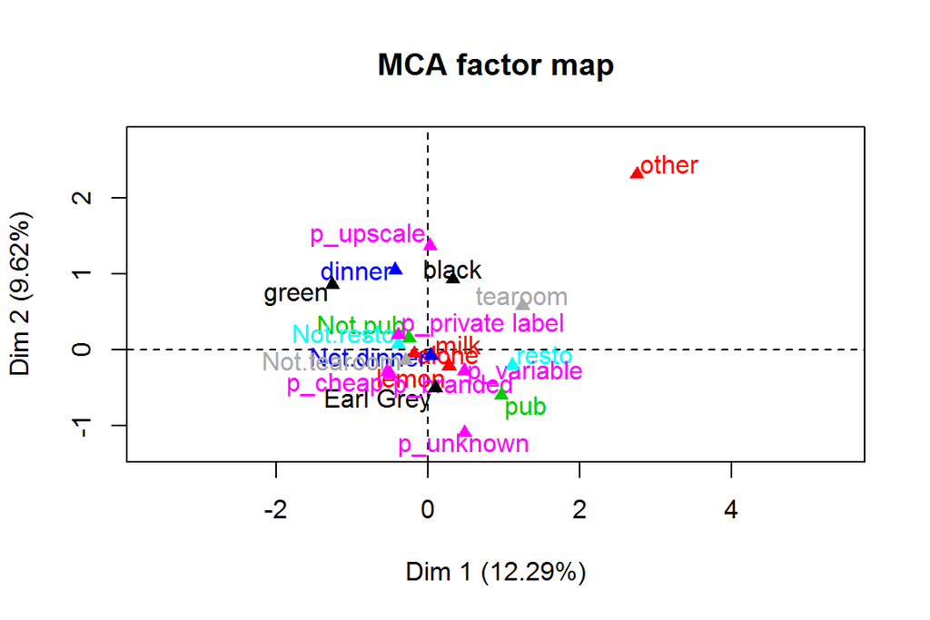

```r
plot(mca_tea, invisible=c("ind"), habillage = "quali")
```

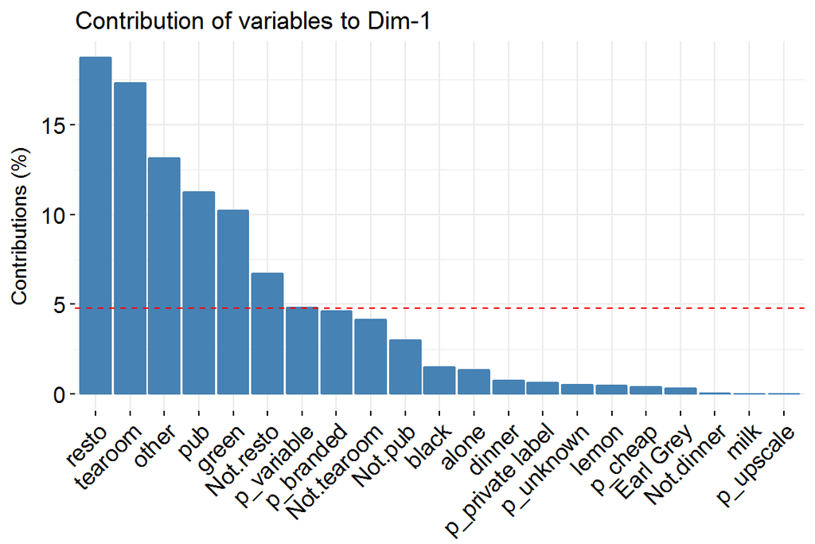

```r
fviz_contrib(mca_tea, choice = "var", axes = 1)
```

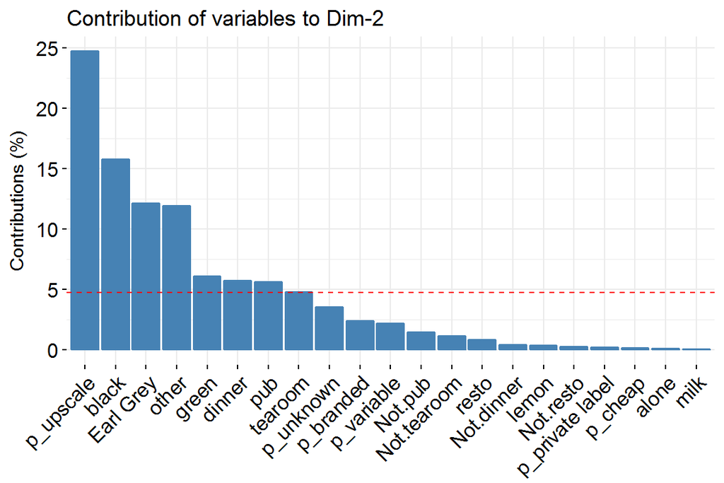

```r
fviz_contrib(mca_tea, choice = "var", axes = 2)
```

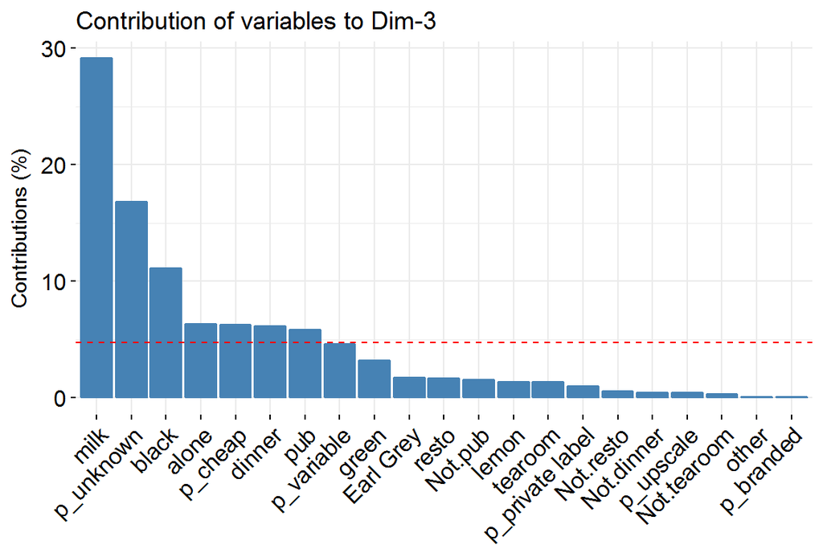

```r
fviz_contrib(mca_tea, choice = "var", axes = 3)
```

The MDA is done 14 dimensions but after first three dimensions explain more variance than others. With three dimensions 31 % of variance is explained. In dimension 1 are variables *resto*, *pub* and *tearoom*, so places where to drink. In dimension 2 are variables *Tea* and *Price*, so variables about the tea. In dimensions 3 are variables *How* and *price*, so other two variables. eta2 table tells correlations between dimensions and variables. With three bar charts tell how different variables contribute to the dimensions. They tell same story than the eta-tables.

Factor map (biplot) is drawn. It is quite hard to interpret. Firstly we can see the “lonely rider”, *other* that indicates that tea is drunk with something else than milk or lemon (that are nearly on origo). Black and green tea are drunk with dinner. Most of points are on the origo so their contributions to the dimensions 1 and 2 are quite low.